# ML 8: Decision Tree & Random Forest

Castillo, Anjelica M.

This notebook demonstrates training and evaluating **Decision Tree** and **Random Forest** classifiers on the popular **Iris dataset**.

### Objectives:

- Load the Iris dataset
- Train Decision Tree and Random Forest classifiers
- Evaluate performance using accuracy, classification report, and confusion matrix
- Visually compare model performance

## Step 1: Load and Inspect the Dataset

We use `sklearn.datasets.load_iris()` to load the Iris dataset. The dataset contains 150 samples from 3 classes of Iris flowers.

```python
import numpy as np
import pandas as pd
from sklearn.datasets import load_iris
from sklearn.model_selection import train_test_split
from sklearn.tree import DecisionTreeClassifier
from sklearn.ensemble import RandomForestClassifier
from sklearn.metrics import accuracy_score, classification_report, confusion_matrix
import matplotlib.pyplot as plt
import seaborn as sns
```

```python
iris = load_iris()
X = iris.data
y = iris.target

iris_df = pd.DataFrame(data=X, columns=iris.feature_names)
iris_df['target'] = y
iris_df['target_name'] = iris_df['target'].apply(lambda i: iris.target_names[i])
iris_df.head()
```

|  | sepal length (cm) | sepal width (cm) | petal length (cm) | petal width (cm) | target | target_name |
| --- | --- | --- | --- | --- | --- | --- |
| 0 | 5.1 | 3.5 | 1.4 | 0.2 | 0 | setosa |
| 1 | 4.9 | 3.0 | 1.4 | 0.2 | 0 | setosa |
| 2 | 4.7 | 3.2 | 1.3 | 0.2 | 0 | setosa |
| 3 | 4.6 | 3.1 | 1.5 | 0.2 | 0 | setosa |
| 4 | 5.0 | 3.6 | 1.4 | 0.2 | 0 | setosa |

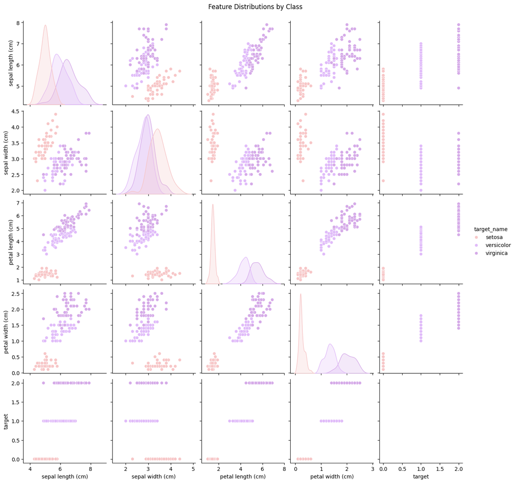

```python
# Custom_palette = ["#f7c6c7", "#e0bbf9", "#d5aae8"]

# Pairplot with custom pastel colors
sns.pairplot(iris_df, hue='target_name', palette=custom_palette, diag_kind='kde')
plt.suptitle("Feature Distributions by Class", y=1.02)
plt.show()
```

## Step 2: Split the Dataset

Split the data into training and test sets (70% train, 30% test) using `train_test_split`.

```python
X_train, X_test, y_train, y_test = train_test_split(X, y, test_size=0.3, random_state=42)
```

## Step 3: Train Classifiers

We train:

- A `DecisionTreeClassifier`
- A `RandomForestClassifier`

```python
dt_model = DecisionTreeClassifier(random_state=42)
dt_model.fit(X_train, y_train)
```

```
DecisionTreeClassifier(random_state=42)
```

```python
rf_model = RandomForestClassifier(random_state=42)
rf_model.fit(X_train, y_train)
```

```
RandomForestClassifier(random_state=42)
```

## Step 4: Evaluate Classifiers

Evaluate both classifiers using:

- Accuracy score
- Classification report (precision, recall, f1-score)
- Confusion matrix

```python
y_pred_dt = dt_model.predict(X_test)
y_pred_rf = rf_model.predict(X_test)
```

```python
accuracy_dt = accuracy_score(y_test, y_pred_dt)
accuracy_rf = accuracy_score(y_test, y_pred_rf)

print(f"Decision Tree Accuracy: {accuracy_dt:.2f}")
print(f"Random Forest Accuracy: {accuracy_rf:.2f}")
```

```
Decision Tree Accuracy: 1.00
Random Forest Accuracy: 1.00
```

```python
print("Classification Report - Decision Tree")
print(classification_report(y_test, y_pred_dt, target_names=iris.target_names))

print("Classification Report - Random Forest")
print(classification_report(y_test, y_pred_rf, target_names=iris.target_names))
```

```
Classification Report - Decision Tree
              precision    recall  f1-score   support

      setosa       1.00      1.00      1.00        19
  versicolor       1.00      1.00      1.00        13
   virginica       1.00      1.00      1.00        13

    accuracy                           1.00        45
   macro avg       1.00      1.00      1.00        45
weighted avg       1.00      1.00      1.00        45

Classification Report - Random Forest
              precision    recall  f1-score   support

      setosa       1.00      1.00      1.00        19
  versicolor       1.00      1.00      1.00        13
   virginica       1.00      1.00      1.00        13

    accuracy                           1.00        45
   macro avg       1.00      1.00      1.00        45
weighted avg       1.00      1.00      1.00        45
```

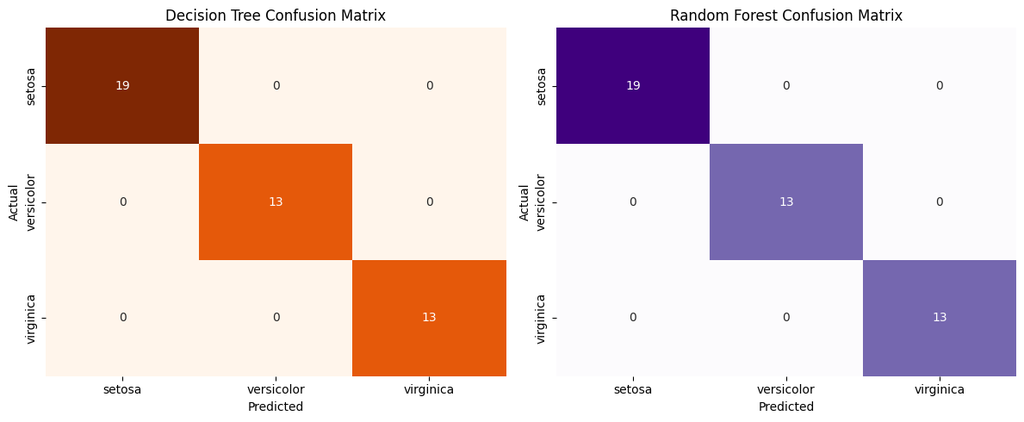

```python
# Compute confusion matrices
cm_dt = confusion_matrix(y_test, y_pred_dt)
cm_rf = confusion_matrix(y_test, y_pred_rf)

# Set up the figure
fig, axes = plt.subplots(1, 2, figsize=(12, 5))

# Plot confusion matrix - Decision Tree
sns.heatmap(cm_dt, annot=True, fmt='d', cmap='Oranges', cbar=False,
            xticklabels=iris.target_names, yticklabels=iris.target_names, ax=axes[0])
axes[0].set_title("Decision Tree Confusion Matrix")
axes[0].set_xlabel("Predicted")
axes[0].set_ylabel("Actual")

# Plot confusion matrix - Random Forest
sns.heatmap(cm_rf, annot=True, fmt='d', cmap='Purples', cbar=False,
            xticklabels=iris.target_names, yticklabels=iris.target_names, ax=axes[1])
axes[1].set_title("Random Forest Confusion Matrix")
axes[1].set_xlabel("Predicted")
axes[1].set_ylabel("Actual")

plt.tight_layout()
plt.show()
```

## Step 5: Visual Comparison

Plot a bar chart to compare the accuracy of both models.

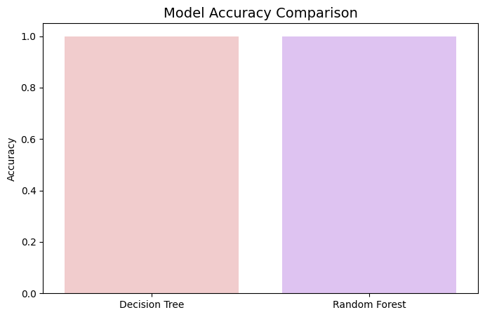

```python
custom_colors = ["#f7c6c7", "#e0bbf9"]

# Bar chart for model accuracy
models = ['Decision Tree', 'Random Forest']
accuracies = [accuracy_dt, accuracy_rf]

plt.figure(figsize=(8, 5))
sns.barplot(x=models, y=accuracies, palette=custom_colors)
plt.title("Model Accuracy Comparison", fontsize=14)
plt.ylabel("Accuracy")
plt.ylim(0, 1.05)
plt.show()
```

# Conclusion

I conducted a comparative analysis of two widely used classification algorithms—Decision Tree and Random Forest—on the well-known Iris dataset. The models were evaluated using accuracy, classification reports, confusion matrices, and visualizations.

**Accuracy**: Both models achieved perfect accuracy (100%) on the test set, showcasing their effectiveness on this dataset.

**Classification** **Reports**: Precision, recall, and F1-scores were all 1.00 across all classes for both models, indicating flawless classification.

**Confusion** **Matrices**: Both confusion matrices were perfectly diagonal, confirming no misclassifications.

While both models performed identically on this clean dataset, Random Forest generally offers better generalization on complex or noisy datasets, thanks to its ensemble approach. Decision Trees, though effective here, may be more susceptible to overfitting in such scenarios.

This analysis highlights that for simple, well-structured datasets like Iris, both models perform exceptionally well. However, for real-world applications, Random Forest is usually the more reliable choice due to its robustness.